# Humpback distribution and sea ice

Ben Weinstein

February 21, 2017

# 1 Project Description

- Global changes in climate will lead to new environments
- A key question is how sensitive animals are to changes in environmental conditions
- When favorable conditions arise, how quickly can animals respond to the availability of new habitat?
- Polar marine ecosystems are particularly vulnerable, given the pronounced effects of climate on local conditions, variable environments, and lack of information on species distributions
- We evaluate the response of two cetacean species to changes in sea-ice cover.

## 1.1 Our aims

- Sea ice trends, by month, over the last 5 years
- Determine the threshold of sea-ice concentration and proximity on whale presence
- Evaluate the phenology of sea-ice timing and whale movement
- Highlight anomalous sea ice conditions
- % Change in available habitat based on variable ice conditions

# 2 Occupancy and ice concentration.

What is the probability of occupancy of a cell as a function of % ice cover.

Associate each argos location with ice cell.

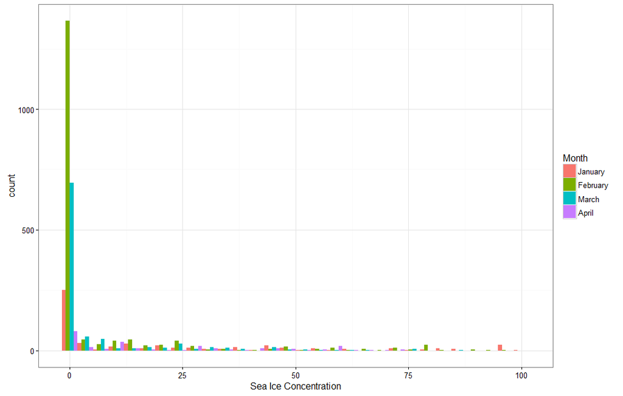

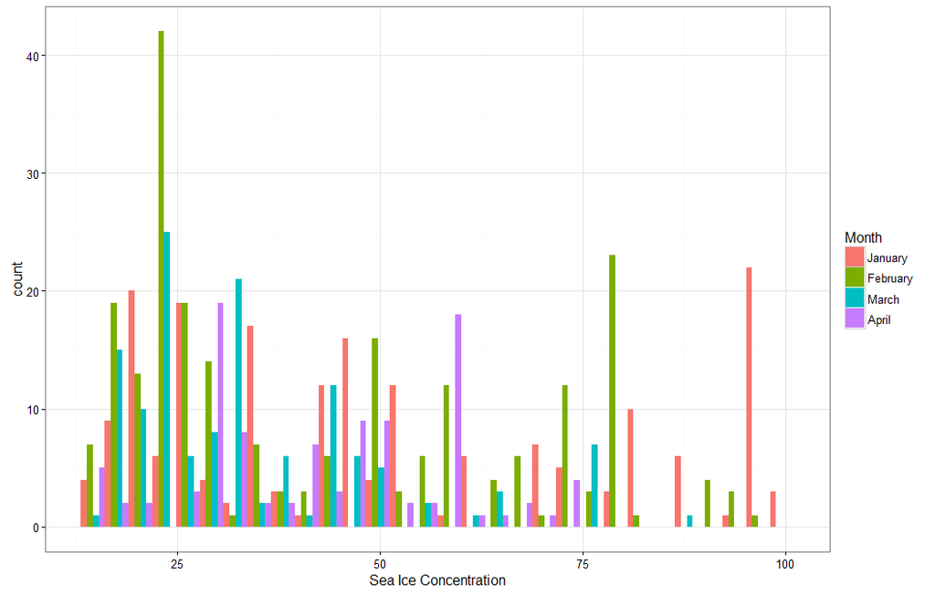

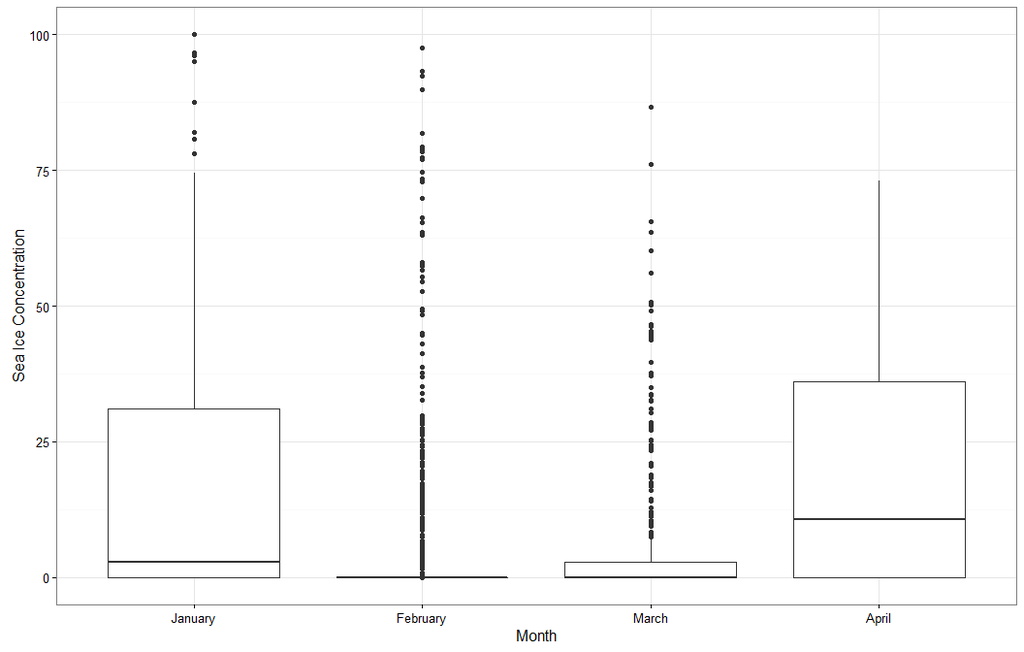

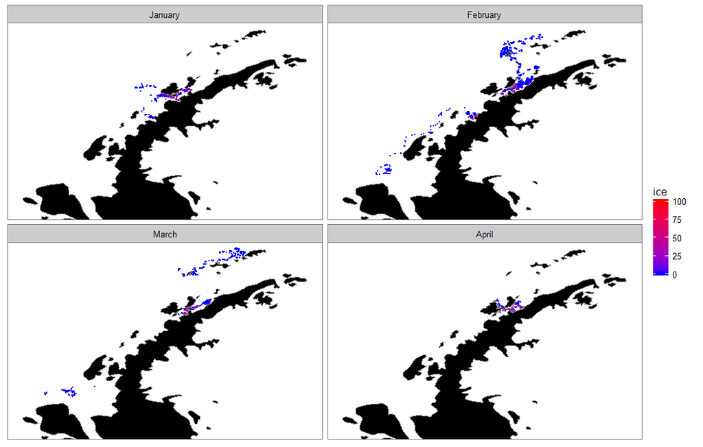

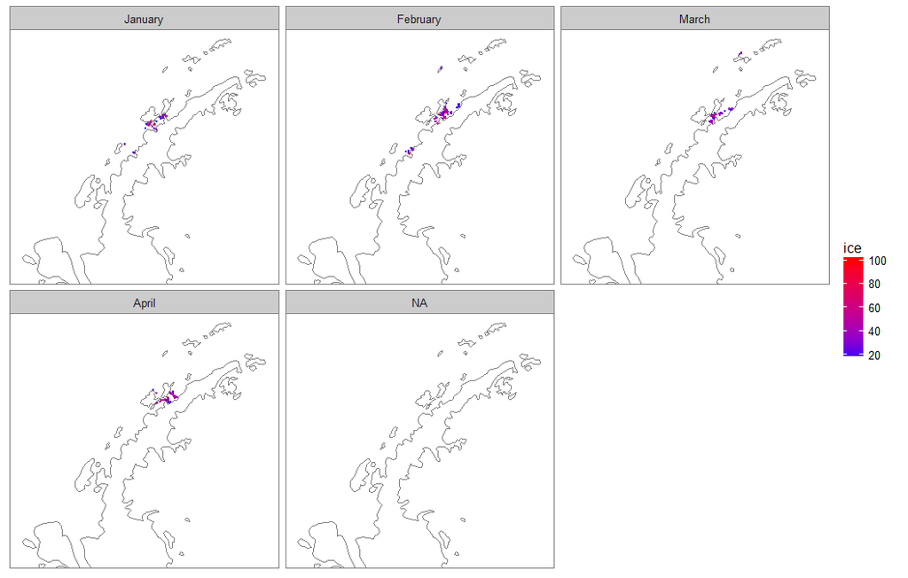

## 2.1 Time integration

Each observation is not independent. In the above analysis a whale popping up 4 times in an hour will recieve the same weight as 4 observations in one day. One approach is to take the average ice concentration among observations and multiply it be the time difference.

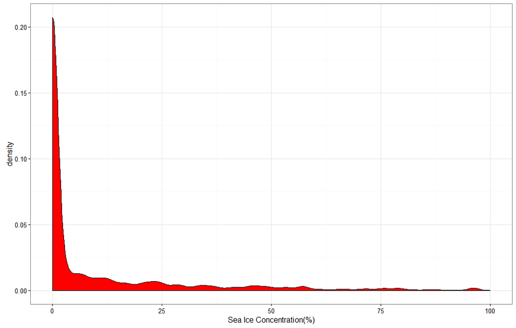

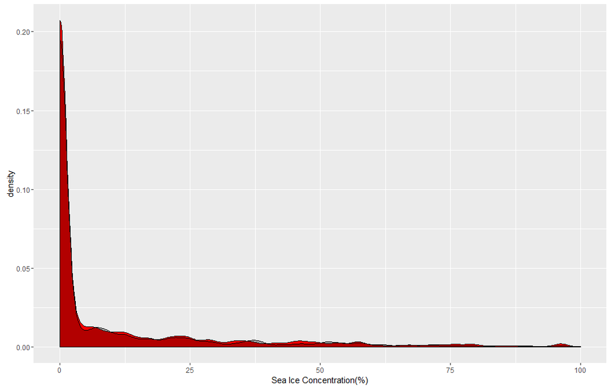

# 3 Null models

## 3.1 Random use

Null use map

For each day, sample randomly in the background points for null values of sea ice concentration.

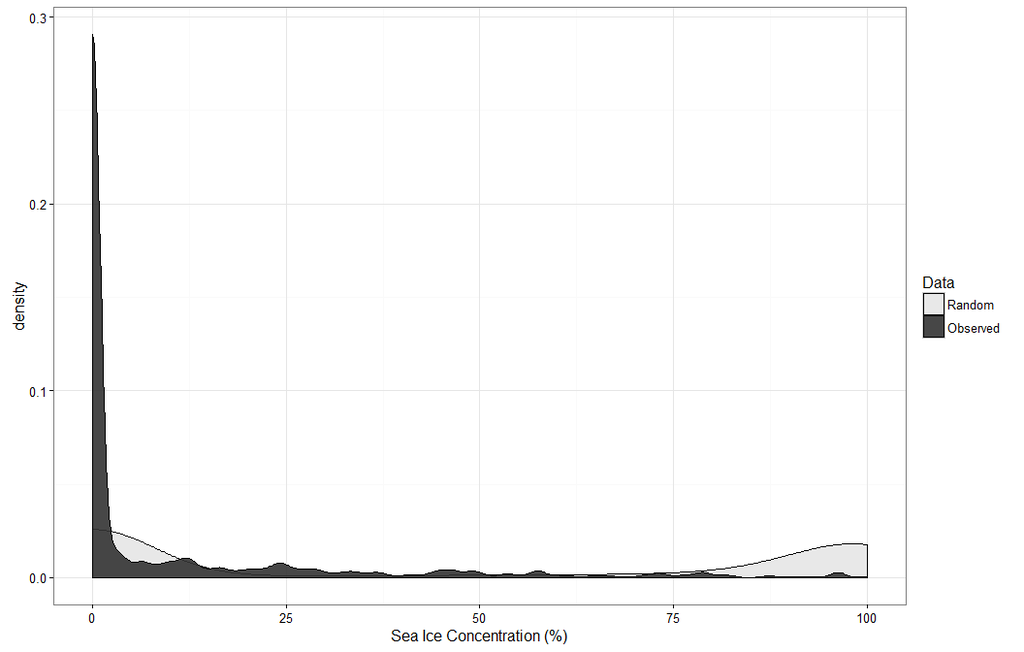

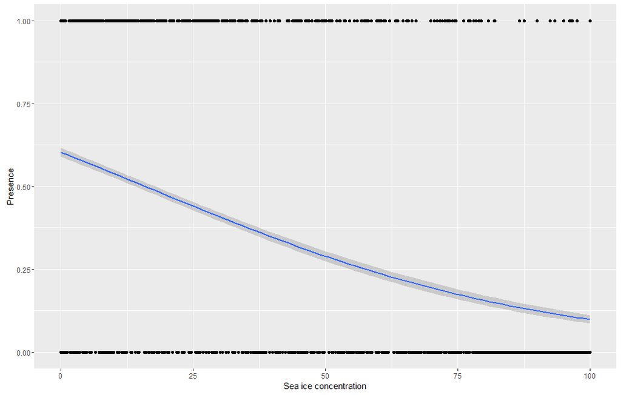

# 4 Distance to ice edge

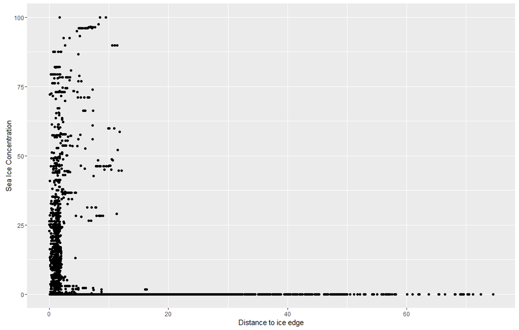

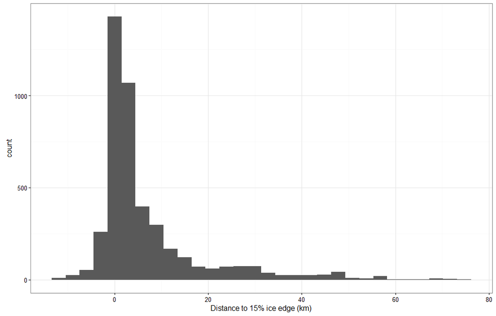

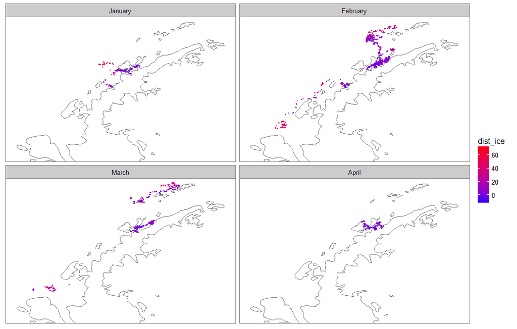

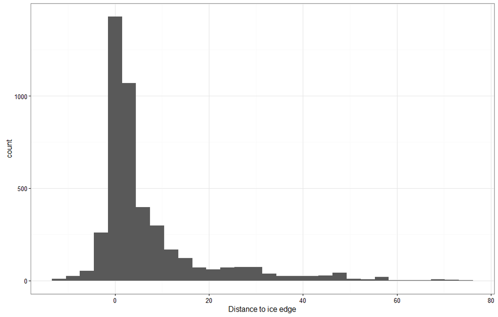

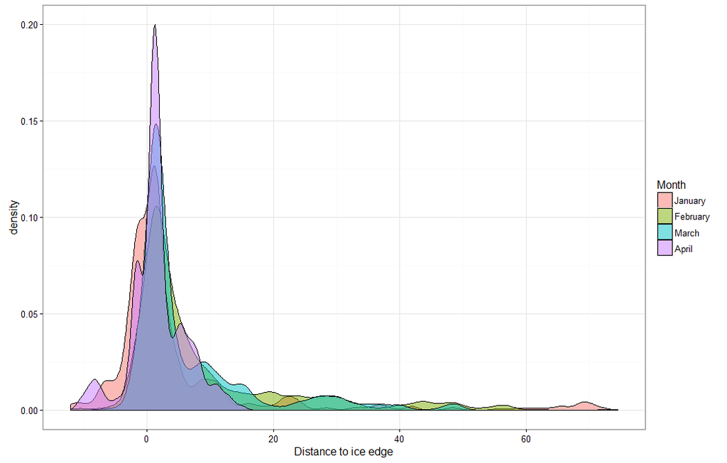

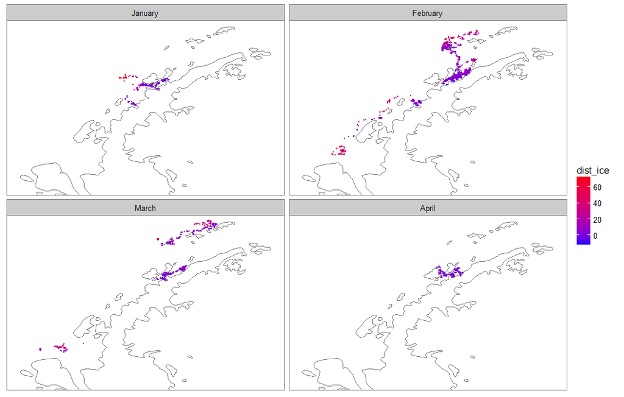

# 5 Temperal window

Sample the cells in a sliding 10 day window

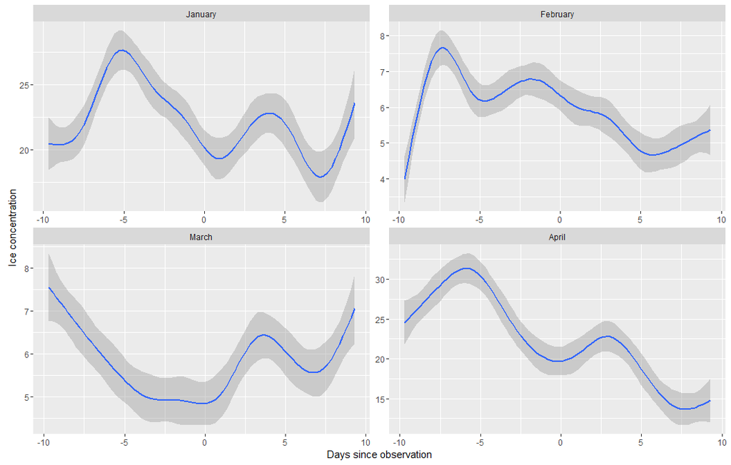

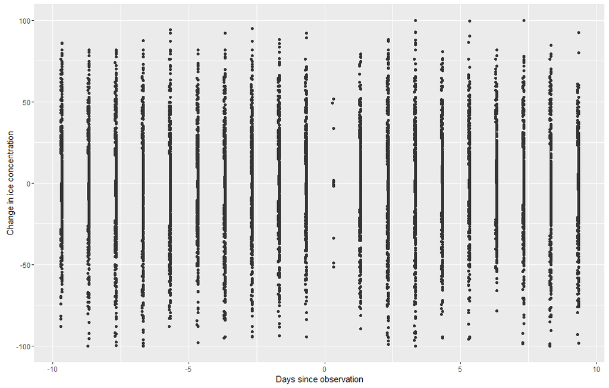

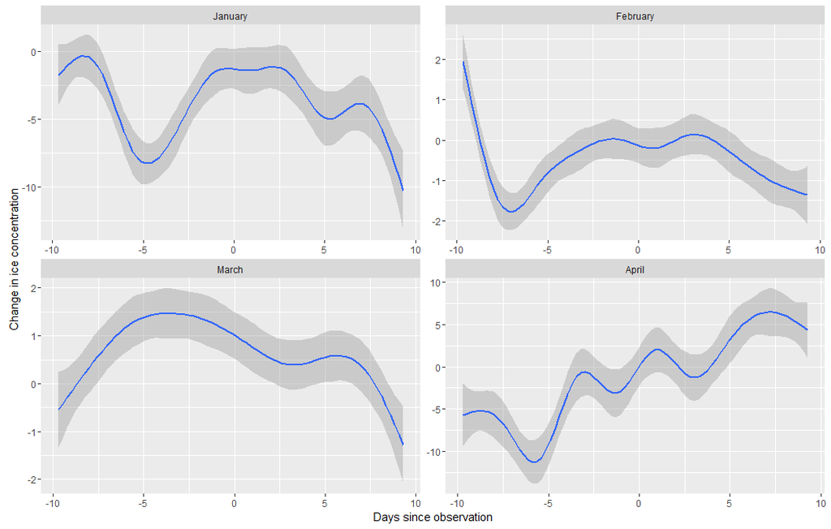

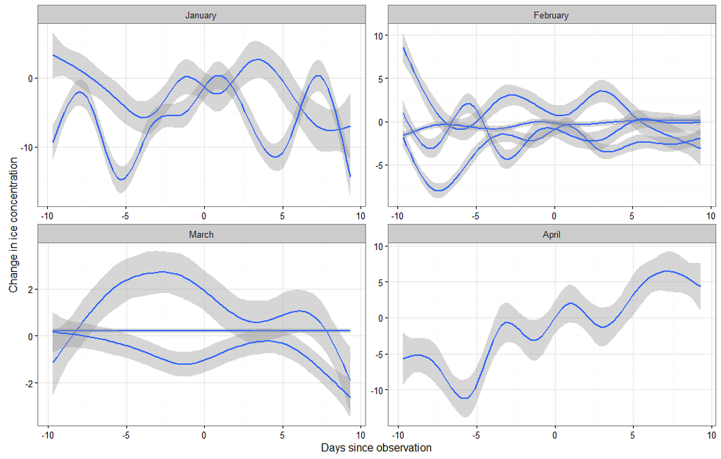